# Waffle Charts

ozge.ozdamar@msgsu.edu.tr

August 15 2022

[figure not shown]

MUSTAFA AKGÜL ÖYYK 2022 - R İLE VERİ GÖRSELLEŞTİRME KURSU EĞİTİM NOTLARI by ozge.ozdamar@msgsu.edu.tr is licensed under a [Creative Commons Attribution-NonCommercial-ShareAlike 4.0 International License](http://creativecommons.org/licenses/by-nc-sa/4.0/).

Hata ve öneriler için ✉️

**REFERENCES**

[waffle paketi](https://github.com/hrbrmstr/waffle)

[ggwaffle paketi](https://liamgilbey.github.io/ggwaffle/)

[Building Waffle Charts](https://rud.is/rpubs/building-waffle-charts.html)

**LIBRARIES**

```r
devtools::install_github("liamgilbey/ggwaffle")
```

```r
.packages = c("waffle", "ggplot2","aplpack","ggwaffle")
.inst <- .packages %in% installed.packages()
if(length(.packages[!.inst]) > 0) install.packages(.packages[!.inst])
lapply(.packages, require, character.only=TRUE)
```

**FUNCTIONS**

```r
aplpack::iconplot()
ggwaffle::
waffle::waffle()
```

# 1 Tarihçe, terminoloji

# 2 Anatomi

# 3 Bize ne söyler?

# 4 Teknik Bilgiler

# 5 Varyasyon ve alternatifler

# 6 Çizim

R’da `waffle` paketi, unit graph, waffle graph ve ikon grap için kullanabiliriz.

**Fonksiyon Argumanları**

```r
waffle(parts, rows = 10, keep = TRUE, xlab = NULL, title = NULL,
  colors = NA, size = 2, flip = FALSE, reverse = FALSE,
  equal = TRUE, pad = 0, use_glyph = FALSE, glyph_size = 12,
  legend_pos = "right")
```

**Arguman açıklamaları**

```r
waffle(parts, # vektör olarak frekans ya da oranlar. vektörün 2 elemanı ve toplam frekans 10 olmaması durumunda 10'a tamamlayacak şekilde 3. eleman eklenir, buna dikkat edilmeli! 2'den fazla eleman olması durumunda,bu geçerli değil. vektör elemanlarının ismi olmaması durumunda sırasıyla harfler atanır.


       rows = 10, #
       keep = TRUE, frekansı olmayan eleman var ise F ile grafikte görüntülenmemesi sağlanır
       xlab = NULL,
       title = NULL,
       colors = NA, # renkler değiştirilmediği sürece otomatik olarak atanır
       size = 2, # kareler arası boşluk aralığı
       flip = FALSE, # yerleştirme yatay ya da dikey olması, TRUE olarak atanmasında
       reverse = FALSE,
       equal = TRUE,
       pad = 0,
       use_glyph = FALSE,
       glyph_size = 12,
       legend_pos = "right")
```

argümanları daha iyi anlamak için:

```r
waffle(c(2,4))
waffle(c(2,4,1))
waffle(c(x1=2,x2=4,x3=1))
waffle(c(2,4,1), rows = 2)
waffle(c(20,30))
waffle(c(20,35))
waffle(c(20,35,12))
waffle(c(20,35), flip = T)
waffle(c(20,35), flip = T, size = 1)
waffle(c(20,35), pad = 4)
waffle(c(20,35), legend_pos = "bottom")
```

```r
PseudoData<-data.frame(x1=c(23,43,54,25,12),x2=c("F","F","M","F","M"),x3=factor(c(2,3,3,1,3)))
row.names(PseudoData)<-c("A","B","C","D","E")
```

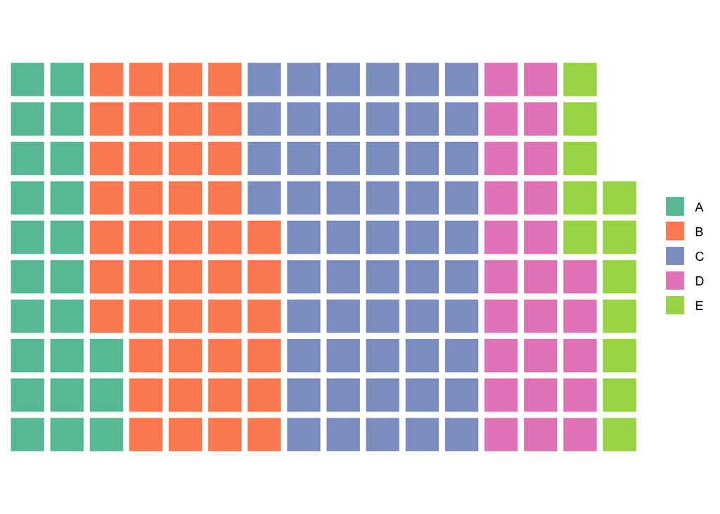

```r
waffle(PseudoData$x1)
```

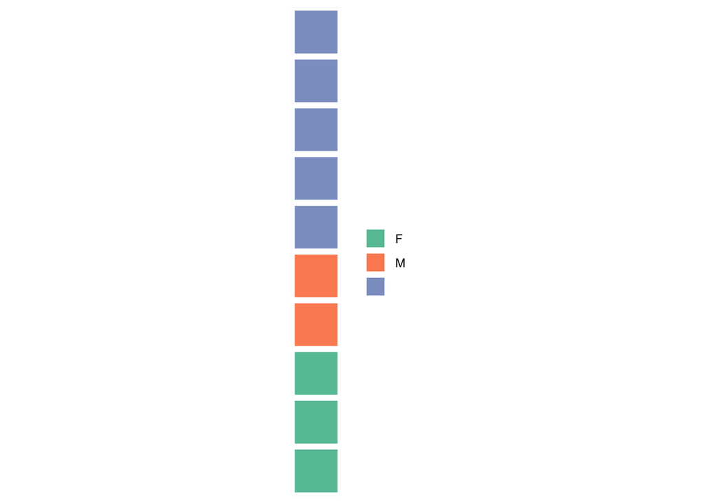

```r
waffle(table(PseudoData$x2))
```

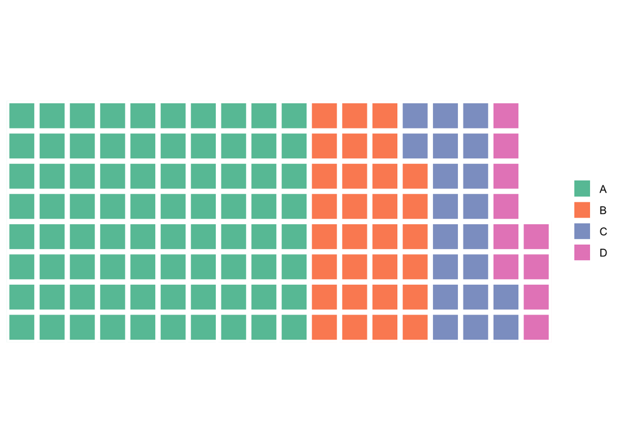

```r
x1 <- c(80, 30, 20, 10)
waffle(x1, rows=8)
```